# Test for association between tobacco consumption and life expectancy, from 1990 to 2010

**Last edited: December 22, 2015**

**Kellie Ottoboni**

```r
set.seed(38)
library(dplyr)
library(Hmisc)
source("../Code/modeling.R")
library(ModelMatch)
```

## Data cleaning

Data cleaning is identical to the sodium analysis.

# Change over time

The first analysis we do looks at *changes* in these variables from 1990 to 2010. By taking the difference between levels in 2010 and 1990, we control for baseline differences between countries. Unfortunately, the measure of smoking that we use (cigarettes per capita, annually) is not split by gender.

```r
countries <- salt2010$country
salt_diff <- salt2010[,-1]-salt1990[,-1]
salt_diff <- cbind(countries, salt_diff)
salt_diff <- filter(salt_diff, !is.na(e0_M))

male <- dplyr::select(salt_diff, e0_M, pc_gdp, Na_M, etohM)
colnames(male) <- gsub("_?M", "", colnames(male))
female <- dplyr::select(salt_diff, e0_F, Na_F, etohF, pc_gdp)
colnames(female) <- gsub("_?F", "", colnames(female))
tobacco <- salt_diff$smoking
```

## Results

### Unadjusted correlation

We begin by looking at the correlation between the change in tobacco consumption and change in life expectancy at age 30.

```r
unadjusted_corr_M <- permu_pearson(prediction = male$e0, response = 0, treatment = tobacco, iters = 10000)
unadjusted_corr_F <- permu_pearson(prediction = female$e0, response = 0, treatment = tobacco, iters = 10000)
```

```
##          Estimate Upper p Lower p Two-sided p
## Male   -0.4106223  0.9951  0.0049      0.0148
## Female -0.1751069  0.8437  0.1563      0.3140
```

### Adjusted for alcohol consumption

Next, we predict change in life expectancy using per capita GDP and alcohol consumption. We look at the correlation between the excess mortality (predicted - actual change in life expectancy) and change in tobacco consumption.

```r
cat('Model selection: male \n')
mod_M_1 <- male %>% select(-Na) %>% choose_model()
pred_M_1 <- predict(mod_M_1, male)
res_M_1 <- permu_pearson(prediction = pred_M_1, response = male$e0, treatment = tobacco, iters = 10000)
cat('Model selection: female \n')
mod_F_1 <- female %>% select(-Na) %>% choose_model()
pred_F_1 <- predict(mod_F_1, female)
res_F_1 <- permu_pearson(prediction = pred_F_1, response = female$e0, treatment = tobacco, iters = 10000)
```

```
## Model selection: male
##
##            Linear regression        Polynomial regression
##                    1.2741506                    1.2741506
##                         CART                  Bagged CART
##                    1.6878900                    1.4265818
##                Random forest Stochastic gradient boosting
##                    0.3091316                    1.1580797
## Model selection: female
##
##            Linear regression        Polynomial regression
##                    0.8176461                    0.8176461
##                         CART                  Bagged CART
##                    1.2395969                    0.7666225
##                Random forest Stochastic gradient boosting
##                    0.2064480                    0.4291248
```

```
##           Estimate Upper p Lower p Two-sided p
## Male    0.20757417  0.1122  0.8878      0.2248
## Female -0.05540284  0.6199  0.3801      0.7524
```

### Adjusted for sodium consumption and alcohol consumption

Finally, we predict change in life expectancy using per capita GDP, Na+ consumption, and alcohol consumption. We look at the correlation between the excess mortality (predicted - actual change in life expectancy) and change in tobacco consumption.

```r
cat('Model selection: male \n')
mod_M <- male %>% choose_model()
pred_M <- predict(mod_M, male)
res_M <- permu_pearson(prediction = pred_M, response = male$e0, treatment = tobacco, iters = 10000)
cat('Model selection: female \n')
mod_F <- female %>% choose_model()
pred_F <- predict(mod_F, female)
res_F <- permu_pearson(prediction = pred_F, response = female$e0, treatment = tobacco, iters = 10000)
```

```
## Model selection: male
##
##            Linear regression        Polynomial regression
##                    1.2736019                    1.2736019
##                         CART                  Bagged CART
##                    1.6878900                    1.4470939
##                Random forest Stochastic gradient boosting
##                    0.3484701                    0.5452434
## Model selection: female
##
##            Linear regression        Polynomial regression
##                    0.7236796                    0.7236796
##                         CART                  Bagged CART
##                    0.7242306                    0.7763061
##                Random forest Stochastic gradient boosting
##                    0.1712111                    0.5621992
```

```
##          Estimate Upper p Lower p Two-sided p
## Male   0.24293709  0.0797  0.9203      0.1613
## Female 0.05053526  0.3770  0.6230      0.7741
```

## Plots

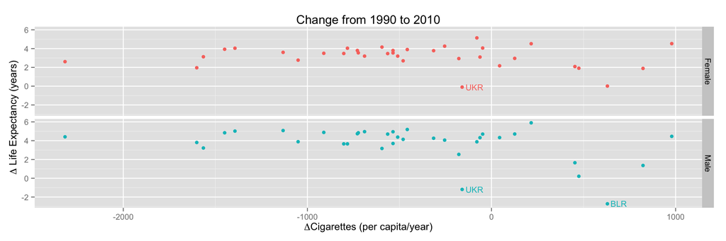

```r
library(ggplot2)

dat <- data.frame("sex"     = c(rep("Male",nrow(male)), rep("Female",nrow(female))),
                  "smoking"  = as.numeric(c(tobacco, tobacco)),
                  "le"      = c(male$e0, female$e0),
                  "country" = rep(salt_diff$countries, 2),
                  "ex_mort" = c(pred_M-male$e0, pred_F-female$e0),
                  stringsAsFactors = FALSE)
p1 <- qplot(smoking, le, data = dat, facets = sex~., colour = sex) + theme(legend.position = "none") + labs(x = expression(paste(Delta, "Cigarettes (per capita/year)")), y = expression(paste(Delta, " Life Expectancy (years)")), title = "Change from 1990 to 2010") + geom_text(aes(label=ifelse(le<0,paste(country),"")) , hjust=-0.2, size = 3.5)
p1
```

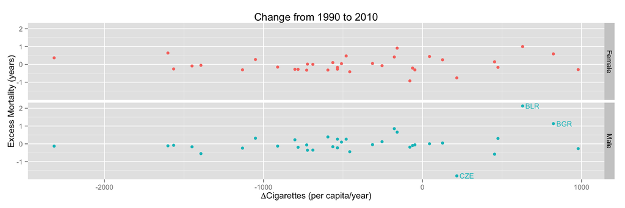

```r
p2 <- qplot(smoking, ex_mort, data = dat, facets = sex~., colour = sex) + theme(legend.position = "none") + labs(x = expression(paste(Delta, "Cigarettes (per capita/year)")), y = "Excess Mortality (years)", title = "Change from 1990 to 2010") + geom_text(aes(label=ifelse(abs(ex_mort) > 1, paste(country), "")), hjust=-0.2, size = 3.5)
p2
```

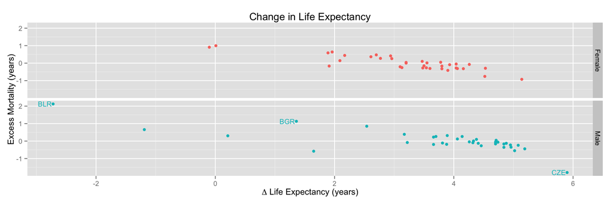

```r
p3 <- qplot(le, ex_mort, data = dat, facets = sex~., colour = sex) + theme(legend.position = "none") + labs(x = expression(paste(Delta, " Life Expectancy (years)")), y = "Excess Mortality (years)", title = "Change in Life Expectancy")  + geom_text(aes(label=ifelse(abs(ex_mort) >1, paste(country), "")), hjust=1.1, size = 3.5)
p3
```

# Absolute associations

The previous analysis accounted for changes in life expectancy and in sodium, alcohol, and tobacco consumption from 1990 to 2010. We also want to look at the correlation between smoking and life expectancy at a fixed point in time, rather than taking differences.

Aside from the data preparation, the analysis is the same as the previous section.

```r
salt_imputed <- rbind(salt1990, salt2010)
salt_imputed <- salt_imputed %>% filter(!is.na(e0_M) & !is.na(e0_F))
male <- dplyr::select(salt_imputed, e0_M, Na_M, etohM, pc_gdp)
colnames(male) <- gsub("_?M", "", colnames(male))
female <- dplyr::select(salt_imputed,  e0_F, Na_F, etohF, pc_gdp)
colnames(female) <- gsub("_?F", "", colnames(female))
tobacco <- salt_imputed$smoking
```

## Results

### Unadjusted correlation

We look at the correlation between tobacco consumption and life expectancy at age 30.

```r
unadjusted_corr_M <- permu_pearson(prediction = male$e0, response = 0, treatment = tobacco, iters = 10000)
unadjusted_corr_F <- permu_pearson(prediction = female$e0, response = 0, treatment = tobacco, iters = 10000)
```

```
##          Estimate Upper p Lower p Two-sided p
## Male   -0.1126294  0.8238  0.1762      0.3512
## Female -0.1382639  0.8744  0.1256      0.2489
```

### Adjusted for alcohol consumption

Next, we predict life expectancy using alcohol consumption and per capita GDP. We look at the correlation between the excess mortality (predicted - actual life expectancy) and tobacco consumption.

```r
cat('Model selection: male \n')
mod_M_1 <- male %>% select(-Na) %>% choose_model()
pred_M_1 <- predict(mod_M_1, male)
res_M_1 <- permu_pearson(prediction = pred_M_1, response = male$e0, treatment = tobacco, iters = 10000)
cat('Model selection: female \n')
mod_F_1 <- female %>% select(-Na) %>% choose_model()
pred_F_1 <- predict(mod_F_1, female)
res_F_1 <- permu_pearson(prediction = pred_F_1, response = female$e0, treatment = tobacco, iters = 10000)
```

```
## Model selection: male
##
##            Linear regression        Polynomial regression
##                     6.120246                     6.120246
##                         CART                  Bagged CART
##                     4.799671                     3.444170
##                Random forest Stochastic gradient boosting
##                     1.263934                     3.215312
## Model selection: female
##
##            Linear regression        Polynomial regression
##                    3.4307459                    3.4307459
##                         CART                  Bagged CART
##                    1.7422838                    1.6349663
##                Random forest Stochastic gradient boosting
##                    0.6085525                    1.6454542
```

```
##         Estimate Upper p Lower p Two-sided p
## Male   0.1228986  0.1584  0.8416      0.3127
## Female 0.2199938  0.0335  0.9665      0.0695
```

### Adjusted for sodium consumption and alcohol consumption

Finally, we predict life expectancy using per capita GDP, sodium consumption, and alcohol consumption. We look at the correlation between the excess mortality (predicted - actual life expectancy) and tobacco consumption.

```r
cat('Model selection: male \n')
mod_M <- male %>% choose_model()
pred_M <- predict(mod_M, male)
res_M <- permu_pearson(prediction = pred_M, response = male$e0, treatment = tobacco, iters = 10000)
cat('Model selection: female \n')
mod_F <- female %>% choose_model()
pred_F <- predict(mod_F, female)
res_F <- permu_pearson(prediction = pred_F, response = female$e0, treatment = tobacco, iters = 10000)
```

```
## Model selection: male
##
##            Linear regression        Polynomial regression
##                     6.098778                     6.098778
##                         CART                  Bagged CART
##                     4.799671                     3.208601
##                Random forest Stochastic gradient boosting
##                     1.078698                     3.203428
## Model selection: female
##
##            Linear regression        Polynomial regression
##                    3.3347770                    3.3347770
##                         CART                  Bagged CART
##                    1.5998213                    1.4601383
##                Random forest Stochastic gradient boosting
##                    0.5093531                    1.5534953
```

```
##         Estimate Upper p Lower p Two-sided p
## Male   0.1341263  0.1341  0.8659      0.2671
## Female 0.2058453  0.0381  0.9619      0.0806
```

### R and package versions used